# stroke_prediction

## Stroke prediction

```python
import pandas as pd
import numpy as np

import matplotlib.pyplot as plt
import seaborn as sns

import os

from sklearn.model_selection import train_test_split
from sklearn.pipeline import Pipeline

# classification
from sklearn.svm import SVC
from sklearn.metrics  import (f1_score ,accuracy_score, confusion_matrix,
                            classification_report, ConfusionMatrixDisplay,
                            roc_curve, precision_recall_curve,
                            auc, make_scorer, recall_score, accuracy_score, precision_score
                            )

from sklearn.model_selection import train_test_split, GridSearchCV, StratifiedKFold

from sklearn.model_selection import cross_val_score

from sklearn.metrics import precision_recall_curve

from sklearn.ensemble import AdaBoostClassifier, RandomForestClassifier
from sklearn.neighbors import KNeighborsClassifier
from sklearn.tree import DecisionTreeClassifier
from xgboost.sklearn import XGBClassifier
from sklearn.naive_bayes import GaussianNB

from sklearn.neural_network import MLPClassifier
from sklearn.svm import SVC
from sklearn.linear_model import LogisticRegression
from sklearn.neighbors import KNeighborsClassifier

from sklearn.preprocessing import LabelEncoder, OneHotEncoder

from sklearn.decomposition import PCA
from sklearn.preprocessing import MinMaxScaler
```

```python
# sns.set_theme(style="ggplot")
```

### Code setup

- df = raw dataset
- df_eng = dataset with BMI values (only nulls in the dataset) imputed and 'yes'/'no' values changed to 0/1

```python
df_path = '../datasets/stroke_data.csv'
df_eng_path = '../datasets/stroke_data_eng.csv'
df_enc_path = '../datasets/stroke_data_enc.csv'
df = pd.read_csv(df_path, index_col=0)
df_eng = pd.read_csv(df_eng_path, index_col=0)
df_enc = pd.read_csv(df_enc_path, index_col=0)
```

#### Columns

```python
cols = df.columns
cols
```

```
Index(['gender', 'age', 'hypertension', 'heart_disease', 'ever_married',
       'work_type', 'Residence_type', 'avg_glucose_level', 'bmi',
       'smoking_status', 'stroke'],
      dtype='object')
```

```python
eng_cols = df_eng.columns
eng_cols
```

```
Index(['gender', 'age', 'hypertension', 'heart_disease', 'ever_married',
       'work_type', 'Residence_type', 'avg_glucose_level', 'bmi',
       'smoking_status', 'stroke'],
      dtype='object')
```

### EDA

#### Datasets heads

```python
df.head()
```

| id | gender | age | hypertension | heart_disease | ever_married | work_type | Residence_type | avg_glucose_level | bmi | smoking_status | stroke |
| --- | --- | --- | --- | --- | --- | --- | --- | --- | --- | --- | --- |
| 9046 | Male | 67.0 | 0 | 1 | Yes | Private | Urban | 228.69 | 36.6 | formerly smoked | 1 |
| 51676 | Female | 61.0 | 0 | 0 | Yes | Self-employed | Rural | 202.21 | NaN | never smoked | 1 |
| 31112 | Male | 80.0 | 0 | 1 | Yes | Private | Rural | 105.92 | 32.5 | never smoked | 1 |
| 60182 | Female | 49.0 | 0 | 0 | Yes | Private | Urban | 171.23 | 34.4 | smokes | 1 |
| 1665 | Female | 79.0 | 1 | 0 | Yes | Self-employed | Rural | 174.12 | 24.0 | never smoked | 1 |

```python
df_eng.head()
```

| id | gender | age | hypertension | heart_disease | ever_married | work_type | Residence_type | avg_glucose_level | bmi | smoking_status | stroke |
| --- | --- | --- | --- | --- | --- | --- | --- | --- | --- | --- | --- |
| 9046 | Male | 67.0 | 0 | 1 | 1 | Private | Urban | 228.69 | 36.600000 | formerly smoked | 1 |
| 51676 | Female | 61.0 | 0 | 0 | 1 | Self-employed | Rural | 202.21 | 28.893237 | never smoked | 1 |
| 31112 | Male | 80.0 | 0 | 1 | 1 | Private | Rural | 105.92 | 32.500000 | never smoked | 1 |
| 60182 | Female | 49.0 | 0 | 0 | 1 | Private | Urban | 171.23 | 34.400000 | smokes | 1 |
| 1665 | Female | 79.0 | 1 | 0 | 1 | Self-employed | Rural | 174.12 | 24.000000 | never smoked | 1 |

```python
df.dtypes
```

```
gender                object
age                  float64
hypertension           int64
heart_disease          int64
ever_married          object
work_type             object
Residence_type        object
avg_glucose_level    float64
bmi                  float64
smoking_status        object
stroke                 int64
dtype: object
```

### Nulls, duplicates etc

```python
df.isnull().sum()
```

```
gender                 0
age                    0
hypertension           0
heart_disease          0
ever_married           0
work_type              0
Residence_type         0
avg_glucose_level      0
bmi                  201
smoking_status         0
stroke                 0
dtype: int64
```

```python
df[df['bmi'].isnull()]
```

[output not shown]

201 rows × 11 columns

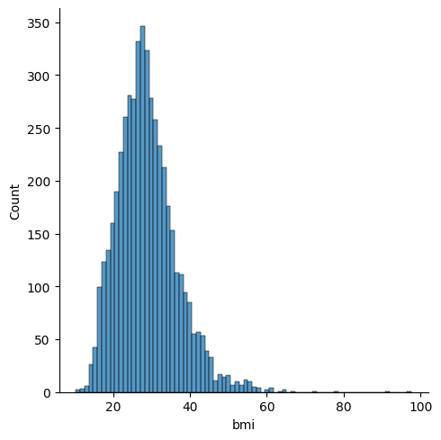

```python
sns.displot(df, x='bmi')
```

```python
df['bmi'].describe()
```

```
count    4909.000000
mean       28.893237
std         7.854067
min        10.300000
25%        23.500000
50%        28.100000
75%        33.100000
max        97.600000
Name: bmi, dtype: float64
```

```python
df['bmi'].median()
```

```
28.1
```

```python
df['bmi'] = df['bmi'].fillna(df['bmi'].mean())
```

```python
df['bmi'].mean()
```

```
28.893236911794663
```

### Handling booleans

```python
df.nunique()
```

```
gender                  3
age                   104
hypertension            2
heart_disease           2
ever_married            2
work_type               5
Residence_type          2
avg_glucose_level    3979
bmi                   419
smoking_status          4
stroke                  2
dtype: int64
```

```python
df.ever_married.unique()
```

```
array(['Yes', 'No'], dtype=object)
```

```python
df[['ever_married']] = df[['ever_married']].replace({'Yes': True, 'No': False})
```

```python
df[['ever_married']] = df[['ever_married']].astype('int')
```

```python
len(cols)
```

```
11
```

### Saving new cleaned df

```python
# df.to_csv("../datasets/stroke_data_eng.csv")
```

### Distribution plots

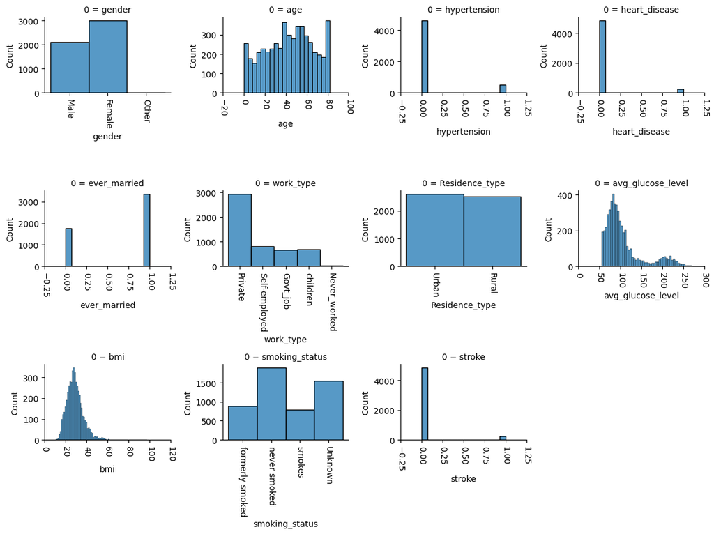

```python
g = sns.FacetGrid(pd.DataFrame(list(cols)), col=0, col_wrap=4, sharex=False, sharey=False)
for ax, col in zip(g.axes, list(cols)):
    sns.histplot(df[col], ax=ax)
g.set_xticklabels(rotation=-90)
g.tight_layout()
```

```python
# Define the number of rows and columns you want
# n_rows=3
# n_cols=4
# # Create the subplots
# fig, axes = plt.subplots(nrows=n_rows, ncols=n_cols)
# for i, column in enumerate(df.columns):
#     sns.histplot(df[column],ax=axes[i//n_cols,i%n_cols])
# fig.tight_layout()
```

### Pairplots

It seem, perhaps expectedly, the data is heavily skewed towards patient with no heart diesease, no hypertension and without having suffered a stroke. Also, about twice of the pasrticipants were ever married, and most work for a private company.

Let's look at some relations between potentially obvious factors and the target

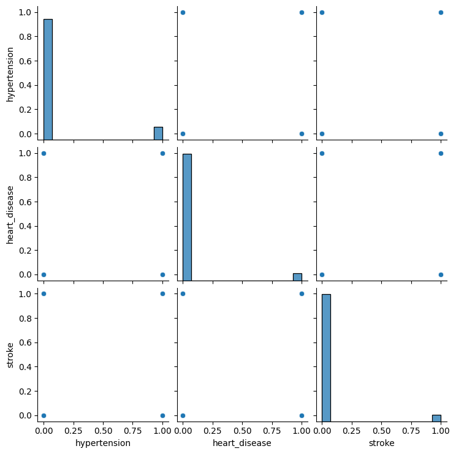

```python
sns.pairplot(df[['hypertension', 'heart_disease', 'stroke', 'smoking_status']])
```

### Stroke vs no stroke explorations

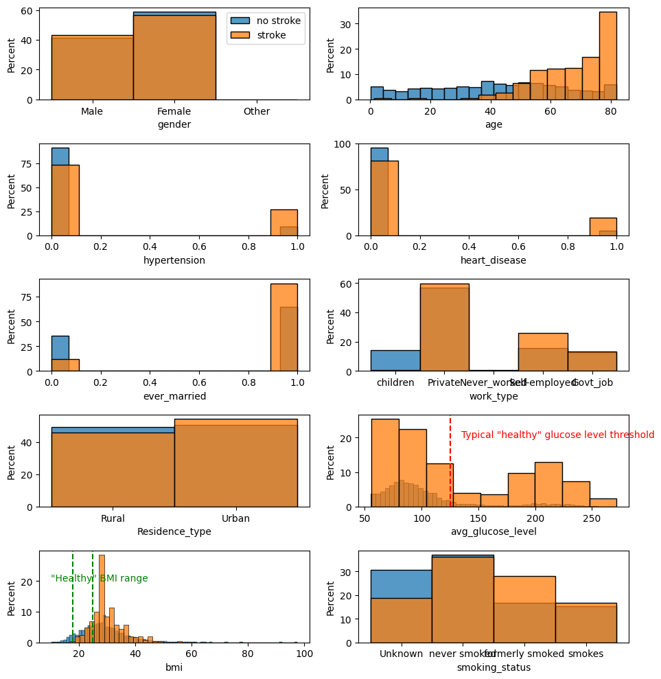

```python
fig, axes = plt.subplots(5,2, figsize=(10,10))
stroke_df = df[df['stroke'] == 1]
nostroke_df = df[df['stroke'] == 0]
cols_no_stroke = [col for col in cols if col != 'stroke']

ax = axes.ravel()

for i in range(10):
    # sns.histplot(data=df, x=cols_no_stroke[i], hue='stroke', stat='density', ax=ax[i])
    sns.histplot(data = nostroke_df, x=cols_no_stroke[i], stat='percent', ax=ax[i])
    sns.histplot(data = stroke_df, x=cols_no_stroke[i], stat='percent', ax=ax[i])

    # additional vertical lines
    dist_col = cols_no_stroke[i]
    if dist_col == 'bmi':
        ax[i].axvline(x=18, ymin=0, ymax=30, color="green", linestyle="dashed")
        ax[i].axvline(x=25, ymin=0, ymax=30, color="green", linestyle="dashed")
        ax[i].text(10, 20, '"Healthy" BMI range', color="green")
    if dist_col == "avg_glucose_level":
        ax[i].axvline(x=125, ymin=0, ymax=30, color="red", linestyle="dashed")
        ax[i].text(135, 20, 'Typical "healthy" glucose level threshold', color="red")
ax[0].legend(['no stroke', 'stroke'], loc='best')
fig.tight_layout()
```

```python
df['stroke'].value_counts()
```

```
stroke
0    4861
1     249
Name: count, dtype: int64
```

Let's calculate how much likely are people to have had hypertension or heart disease if they suffered a stroke compared to if they hadn't, by calculating the percentages within the group

```python
stroke_nostroke_df = pd.DataFrame(columns=['stroke', 'no stroke'])
stroke_nostroke_df

#hypertension
stroke_hypertension = stroke_df[['hypertension']].value_counts()
nostroke_hypertension = nostroke_df[['hypertension']].value_counts()
new_row = {
    'stroke': stroke_hypertension[1] * 100 / stroke_hypertension[0],
    'no stroke': nostroke_hypertension[1] * 100 / nostroke_hypertension[0]
}
new_df = pd.DataFrame([new_row])
new_df.index = ['hypertension']

stroke_nostroke_df = pd.concat([stroke_nostroke_df, new_df])

# heart disease
stroke_heart = stroke_df[['heart_disease']].value_counts()
nostroke_heart = nostroke_df[['heart_disease']].value_counts()

new_row = {
    'stroke': stroke_heart[1] * 100 / stroke_heart[0],
    'no stroke': nostroke_heart[1] * 100 / nostroke_heart[0]
}

new_df = pd.DataFrame([new_row])
new_df.index = ['heart_disease']

stroke_nostroke_df = pd.concat([stroke_nostroke_df, new_df])

# smoking status
stroke_smokes = stroke_df[['smoking_status']].value_counts()
nostroke_smokes = nostroke_df[['smoking_status']].value_counts()

new_row = {
    'stroke': (stroke_smokes[1] + stroke_smokes[3])  * 100 / (stroke_smokes[0] + stroke_smokes[2]),
    'no stroke': (nostroke_smokes[1] + nostroke_smokes[3])  * 100 / (nostroke_smokes[0] + nostroke_smokes[2]),
}

new_df = pd.DataFrame([new_row])
new_df.index = ['smokes']

stroke_nostroke_df = pd.concat([stroke_nostroke_df, new_df])

stroke_nostroke_df['proportion'] = stroke_nostroke_df['stroke'] / stroke_nostroke_df['no stroke']
stroke_nostroke_df
```

|  | stroke | no stroke | proportion |
| --- | --- | --- | --- |
| hypertension | 36.065574 | 9.753895 | 3.697556 |
| heart_disease | 23.267327 | 4.943869 | 4.706299 |
| smokes | 81.751825 | 85.747039 | 0.953407 |

It would seem that patients who suffer a stroke are about 3.7 times as likely to have hypertension and about 4.7 times as likely to have had problems with heart disease. Interestingly, in this dataset the percentage of smoking patients doesnt seem to be related to the chance of suffering a stroke, even though, it is often thought of as a possible important factor

Looking at percentage comparisons:

- Almost all of the patients who suffered a stroke were over the age of 40
- The above calculations related to hypertension and heart disease
- Most who have suffered a stroke are outside the typically cited "healthy" BMI range
- There's a noticeable, but not as significant relation to having been married and suffering a stroke

### Encoding - Label encoding and One Hot

```python
df_enc = df_eng.copy()
```

```python
df_eng.head()
```

| id | gender | age | hypertension | heart_disease | ever_married | work_type | Residence_type | avg_glucose_level | bmi | smoking_status | stroke |
| --- | --- | --- | --- | --- | --- | --- | --- | --- | --- | --- | --- |
| 9046 | Male | 67.0 | 0 | 1 | 1 | Private | Urban | 228.69 | 36.600000 | formerly smoked | 1 |
| 51676 | Female | 61.0 | 0 | 0 | 1 | Self-employed | Rural | 202.21 | 28.893237 | never smoked | 1 |
| 31112 | Male | 80.0 | 0 | 1 | 1 | Private | Rural | 105.92 | 32.500000 | never smoked | 1 |
| 60182 | Female | 49.0 | 0 | 0 | 1 | Private | Urban | 171.23 | 34.400000 | smokes | 1 |
| 1665 | Female | 79.0 | 1 | 0 | 1 | Self-employed | Rural | 174.12 | 24.000000 | never smoked | 1 |

```python
df_eng.nunique()
```

```
gender                  3
age                   104
hypertension            2
heart_disease           2
ever_married            2
work_type               5
Residence_type          2
avg_glucose_level    3979
bmi                   419
smoking_status          4
stroke                  2
dtype: int64
```

```python
df_eng.dtypes
```

```
gender                object
age                  float64
hypertension           int64
heart_disease          int64
ever_married           int64
work_type             object
Residence_type        object
avg_glucose_level    float64
bmi                  float64
smoking_status        object
stroke                 int64
dtype: object
```

#### Since work type, residence type and gender are not hierarchical, we will hot-encode them

```python
dummy_cols = ['gender', 'work_type', 'Residence_type']
for col in dummy_cols:
    one_hot = pd.get_dummies(df[col])
    # drop the original column
    df_enc = df_enc.drop(col, axis=1)
    # add / join the encoded df
    df_enc = df_enc.join(one_hot)
```

| id | age | hypertension | heart_disease | ever_married | avg_glucose_level | bmi | smoking_status | stroke | Female | Male | Other | Govt_job | Never_worked | Private | Self-employed | children | Rural | Urban |
| --- | --- | --- | --- | --- | --- | --- | --- | --- | --- | --- | --- | --- | --- | --- | --- | --- | --- | --- |
| 9046 | 67.0 | 0 | 1 | 1 | 228.69 | 36.600000 | formerly smoked | 1 | False | True | False | False | False | True | False | False | False | True |
| 51676 | 61.0 | 0 | 0 | 1 | 202.21 | 28.893237 | never smoked | 1 | True | False | False | False | False | False | True | False | True | False |
| 31112 | 80.0 | 0 | 1 | 1 | 105.92 | 32.500000 | never smoked | 1 | False | True | False | False | False | True | False | False | True | False |
| 60182 | 49.0 | 0 | 0 | 1 | 171.23 | 34.400000 | smokes | 1 | True | False | False | False | False | True | False | False | False | True |
| 1665 | 79.0 | 1 | 0 | 1 | 174.12 | 24.000000 | never smoked | 1 | True | False | False | False | False | False | True | False | True | False |

#### 'smoking_status' could be considered hierarchical, with a scale from unknown to smoking

```python
df_enc['smoking_status'] = df_eng['smoking_status'].map({'Unknown': -1, 'never smoked': 0, 'formerly smoked': 1, 'smokes':2})
```

```python
df_enc.head()
```

| id | age | hypertension | heart_disease | ever_married | avg_glucose_level | bmi | smoking_status | stroke | Female | Male | Other | Govt_job | Never_worked | Private | Self-employed | children | Rural | Urban |
| --- | --- | --- | --- | --- | --- | --- | --- | --- | --- | --- | --- | --- | --- | --- | --- | --- | --- | --- |
| 9046 | 67.0 | 0 | 1 | 1 | 228.69 | 36.600000 | 1 | 1 | False | True | False | False | False | True | False | False | False | True |
| 51676 | 61.0 | 0 | 0 | 1 | 202.21 | 28.893237 | 0 | 1 | True | False | False | False | False | False | True | False | True | False |
| 31112 | 80.0 | 0 | 1 | 1 | 105.92 | 32.500000 | 0 | 1 | False | True | False | False | False | True | False | False | True | False |
| 60182 | 49.0 | 0 | 0 | 1 | 171.23 | 34.400000 | 2 | 1 | True | False | False | False | False | True | False | False | False | True |
| 1665 | 79.0 | 1 | 0 | 1 | 174.12 | 24.000000 | 0 | 1 | True | False | False | False | False | False | True | False | True | False |

#### Saving the encoded dataset

```python
df_enc.to_csv('../datasets/stroke_data_enc.csv')
```

### Dimensionality reduction exploration

```python
df_enc_smoking = df_eng.copy()
df_enc_smoking['smoking_status'] = df_eng['smoking_status'].map({'Unknown': -1, 'never smoked': 0,
                                                                 'formerly smoked': 1, 'smokes':2})
df_enc_smoking.head()
```

| id | gender | age | hypertension | heart_disease | ever_married | work_type | Residence_type | avg_glucose_level | bmi | smoking_status | stroke |
| --- | --- | --- | --- | --- | --- | --- | --- | --- | --- | --- | --- |
| 9046 | Male | 67.0 | 0 | 1 | 1 | Private | Urban | 228.69 | 36.600000 | 1 | 1 |
| 51676 | Female | 61.0 | 0 | 0 | 1 | Self-employed | Rural | 202.21 | 28.893237 | 0 | 1 |
| 31112 | Male | 80.0 | 0 | 1 | 1 | Private | Rural | 105.92 | 32.500000 | 0 | 1 |
| 60182 | Female | 49.0 | 0 | 0 | 1 | Private | Urban | 171.23 | 34.400000 | 2 | 1 |
| 1665 | Female | 79.0 | 1 | 0 | 1 | Self-employed | Rural | 174.12 | 24.000000 | 0 | 1 |

```python
df_enc_smoking.dtypes
```

```
gender                object
age                  float64
hypertension           int64
heart_disease          int64
ever_married           int64
work_type             object
Residence_type        object
avg_glucose_level    float64
bmi                  float64
smoking_status         int64
stroke                 int64
dtype: object
```

```python
df_enc_smoking.shape[1]
```

```
11
```

```python
df_enc_smoking_num = df_enc_smoking.select_dtypes(include='number')
```

```python
df_enc_smoking_num.shape[1]
```

```
8
```

#### Scaling options

- as the dimensionality reduction algorithms will work better with scaled features
- but also as a useful normalization tool for the dataset

```python
scaler = MinMaxScaler()
scaler.fit(df_enc)
df_enc_scaled = scaler.transform(df_enc)
```

#### PCA with one-hot columns

```python
pca = PCA(n_components=2)
pca.fit(df_enc_scaled)

X_pca = pca.transform(df_enc_scaled)
```

```python
X_pca.shape
```

```
(5110, 2)
```

```python
y = df_enc['stroke']
```

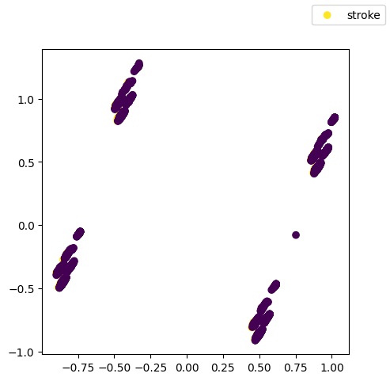

```python
fig = plt.figure(1, figsize=(5,5))
ax = fig.add_subplot(111)
ax.scatter(X_pca[:,0], X_pca[:,1], c=y)
fig.legend(['stroke', 'no stroke'])
```

Not especially useful unfortunately, as the classes overlay, then again PCA may not work the best with one-hot encoded features

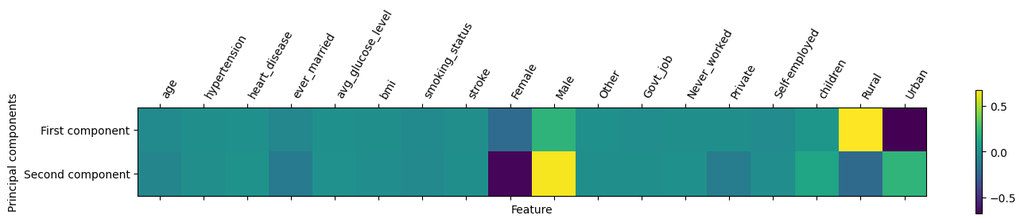

```python
plt.matshow(pca.components_, cmap='viridis')
plt.yticks([0,1], ["First component", "Second component"])
plt.colorbar()
plt.xticks(range(len(df_enc.columns)),
           df_enc.columns, rotation=60, ha='left')
plt.xlabel("Feature")
plt.ylabel("Principal components")
```

#### PCA no one-hot encoded columns

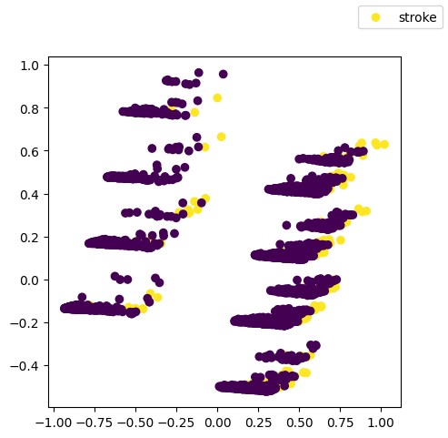

```python
scaler = MinMaxScaler()
scaler.fit(df_enc_smoking_num)
df_enc_smoking_scaled = scaler.transform(df_enc_smoking_num)
pca = PCA(n_components=2)
pca.fit(df_enc_smoking_scaled)

X_pca = pca.transform(df_enc_smoking_scaled)
y = df_enc_smoking['stroke']

fig = plt.figure(1, figsize=(5,5))
ax = fig.add_subplot(111)
ax.scatter(X_pca[:,0], X_pca[:,1], c=y)
fig.legend(['stroke', 'no stroke'])
```

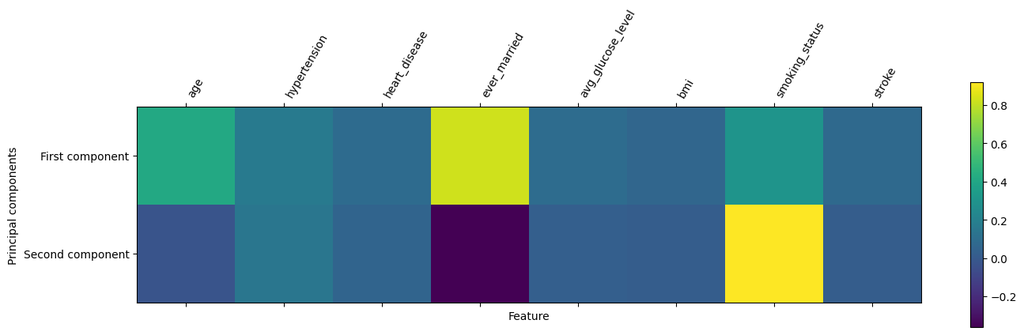

```python
plt.matshow(pca.components_, cmap='viridis')
plt.yticks([0,1], ["First component", "Second component"])
plt.colorbar()
plt.xticks(range(len(df_enc_smoking_num.columns)),
           df_enc_smoking_num.columns, rotation=60, ha='left')
plt.xlabel("Feature")
plt.ylabel("Principal components")
```

What can this tell us about the data and the possibility of predicting the occurence of a stroke? Bearing in mid, such dimensionality reduction algorithms can only approximately suggest trends / relation in the dataset.

## Baseline training

Before going further into feature selection, engineering and any kind of tuning it is important to establish a baseline performance using a simple model, to estimate our expectations and establish the possible range of improvement

### Using the base dataset (with nulls imputed) and categorical variables encoded

#### Random Forests and feature importance

```python
X = df_enc.drop(['stroke'], axis=1)
y = df_enc['stroke']
```

```python
feature_names = list(X.columns)
feature_names
```

```
['age',
 'hypertension',
 'heart_disease',
 'ever_married',
 'avg_glucose_level',
 'bmi',
 'smoking_status',
 'Female',
 'Male',
 'Other',
 'Govt_job',
 'Never_worked',
 'Private',
 'Self-employed',
 'children',
 'Rural',
 'Urban']
```

```python
X_train, X_test, y_train, y_test = train_test_split(X, y, stratify=y, random_state=1)
```

```python
forest = RandomForestClassifier(random_state=1)
forest.fit(X_train, y_train)
```

```
RandomForestClassifier(random_state=1)
```

```python
preds = forest.predict(X_test)
acc = accuracy_score(y_test, preds)
acc
```

```
0.9491392801251957
```

A 95% accuracy on the first tested, simple model - impressive. To eliminate the chance of test sample selection influencing the results, let's try crossvaliating on the dataset.

```python
print(cross_val_score(forest, X, y, cv=5))
```

```
[0.94911937 0.95009785 0.94716243 0.94911937 0.95009785]
```

It would seem the accuracy score is not sensitive to the test sample split over the whole dataset.

### Baseline chance-based prediction

Bearing in mind, the imbalance of the dataset, let's check the accuracy, if we only predicted that no stroke happened (as it is the majority class)

```python
1 - y.mean()
```

```
0.9512720156555773
```

As suspected, such an approach would give us a 95% chance of being right. However, it is extremely important to keep in mind - what is our actual goal here? Do we want to just achieve a highest accuracy chance, or would we be more interested in being correct in predicting a stroke, when the patient is in actual risk of suffering a stroke, ignoring (or neglecting) the possibility of false positives, as a better outcome than a false negative, which could risk a patient at risk. In other words - the precision / recall tradeoff, where, with these circumstances, recall would be the target metric.

```python
precision, recall, _ = precision_recall_curve(y_test, preds)
print(f'precision: {precision}, recall: {recall}')
```

```
precision: [0.0485133 0.        1.       ], recall: [1. 0. 0.]
```

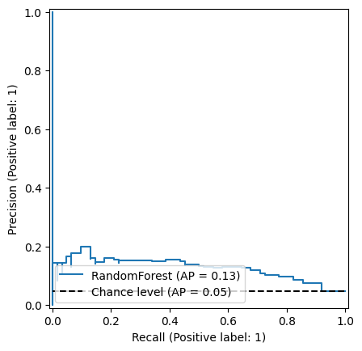

```python
from sklearn.metrics import PrecisionRecallDisplay

display = PrecisionRecallDisplay.from_estimator(
forest, X_test, y_test, name="RandomForest", plot_chance_level = True, pos_label=1
)
# _ = display.ax_.set_title("2-class Precision-Recall curve")
# display.plot()
```

#### precision-recall report per-class

```python
from sklearn.metrics import classification_report
```

```python
forest_report = classification_report(y_test, preds, target_names=['no stroke', 'stroke'])
print(forest_report)
```

```
              precision    recall  f1-score   support

   no stroke       0.95      1.00      0.97      1216
      stroke       0.00      0.00      0.00        62

    accuracy                           0.95      1278
   macro avg       0.48      0.50      0.49      1278
weighted avg       0.91      0.95      0.93      1278
```

It seems both the recall and precision for datapoints with a stroke are 0, meaning the model has not predicted accuretaly for this class once! Let's examine this further

```python
is_right = pd.DataFrame()
is_right['test'] = y_test
is_right['pred'] = preds
is_right['correct'] = (y_test == preds)
```

```python
is_right[is_right['test'] == 1].sample(5)
```

| id | test | pred | correct |
| --- | --- | --- | --- |
| 66866 | 1 | 0 | False |
| 61843 | 1 | 0 | False |
| 58978 | 1 | 0 | False |
| 4651 | 1 | 0 | False |
| 64373 | 1 | 0 | False |

```python
is_right[is_right['test']==1].sum()
```

```
test       62.0
pred        0.0
correct     0.0
dtype: float64
```

It is indeed so, quite bad.  
But, it is only our baseline model, let's continue further to try to improve that!

Still, we can look at feature importances

```python
importances = forest.feature_importances_
for i, feature in enumerate(importances):
    print(feature_names[i], ': ', importances[i])
```

```
age :  0.2392825195264954
hypertension :  0.025741671655392
heart_disease :  0.02405315697909841
ever_married :  0.01952962590167806
avg_glucose_level :  0.267832998118637
bmi :  0.22531654469984763
smoking_status :  0.06809091937195859
Female :  0.018359825812997284
Male :  0.018370524449082735
Other :  3.1844143421913566e-09
Govt_job :  0.014837488811604788
Never_worked :  5.322966245551069e-06
Private :  0.021088351189374115
Self-employed :  0.0187558637202139
children :  0.0009221008316577808
Rural :  0.017833631117916665
Urban :  0.019979451663385883
```

### Moving the classification threshold

By default, binary classifiers in sklearn, regardless of class distribution, will set the classification threshold at 0.5, meaning, assuming that the predictions should more or less be split evenly between the classes, if such a balance exists in the dataset. As seen, our dataset does not fit such criterion. Especially when looking at the precision-recall curve, we can see, the chance model operating on a much lower/higher threshold and our curve following suit. Therefore, let's try moving the prediction threshold closer to one of the classes, hopefully achieving better results for the minority class.

```python
preds_thresh = forest.predict_proba(X_test)
preds_thresh
```

```
array([[0.88, 0.12],
       [0.91, 0.09],
       [0.87, 0.13],
       ...,
       [0.9 , 0.1 ],
       [1.  , 0.  ],
       [1.  , 0.  ]])
```

Looking at the probabilities for each class, indeed we can see, the model is typically very sure of the predictions belonging to class 0 (majority), therefore, the default threshold of 0.5 is not having any effect on the results

```python
preds_thresh[:,0].mean()
```

```
0.9459467918622849
```

```python
preds_thresh[:,1].mean()
```

```
0.05405320813771519
```

Interestingly, when looking at the means of the prediction probabilities, we get a proportion very similar to the proportion of the classes in our data.

```python
preds_thresh = (forest.predict_proba(X_test)[:,1] >= 0.1).astype('int')
preds_thresh
```

```
array([1, 0, 1, ..., 1, 0, 0])
```

```python
unique, counts = np.unique(preds_thresh, return_counts=True)
print(np.asarray((unique, counts)).T)
```

```
[[   0 1017]
 [   1  261]]
```

It seems we might have gone overboard with the threshold, still, let's examine some scoring reports

```python
forest_report_thresh = classification_report(y_test, preds_thresh, target_names=['no stroke', 'stroke'])
print(forest_report_thresh)
```

```
              precision    recall  f1-score   support

   no stroke       0.97      0.81      0.89      1216
      stroke       0.13      0.55      0.21        62

    accuracy                           0.80      1278
   macro avg       0.55      0.68      0.55      1278
weighted avg       0.93      0.80      0.85      1278
```

```python
acc_thresh = accuracy_score(y_test, preds_thresh)
acc_thresh
```

```
0.8004694835680751
```

Indeed, the overall resultant accuracy got lowered quite a bit, still, the recall for class 1 (stroke) jumped from 0 to 0.55. Quite impressive!

```
<sklearn.metrics._plot.confusion_matrix.ConfusionMatrixDisplay at 0x18ef2f94550>
```

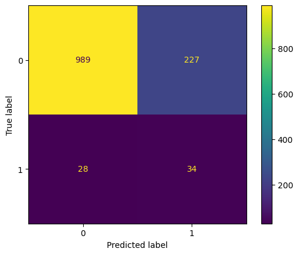

```python
cm_thresh = confusion_matrix(y_test, preds_thresh)
cm_disp_thresh = ConfusionMatrixDisplay(confusion_matrix=cm_thresh,
                              display_labels=forest.classes_)
cm_disp_thresh.plot()
```

Indeed, we are correctly predicting on about over half of the stroke cases, whilst our accuracy of cases of no stroke fell from 100% to about 80%. Let's try to tune the threshold further, before, if necessary, turning to more complex or more finetuned models.

```
counts:
[[  0 861]
 [  1 417]]
report:
              precision    recall  f1-score   support

   no stroke       0.98      0.69      0.81      1216
      stroke       0.11      0.73      0.19        62

    accuracy                           0.70      1278
   macro avg       0.54      0.71      0.50      1278
weighted avg       0.94      0.70      0.78      1278
```

```
<sklearn.metrics._plot.confusion_matrix.ConfusionMatrixDisplay at 0x18ef350e860>
```

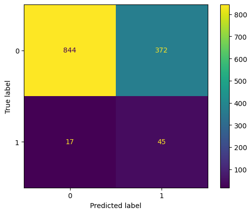

```python
preds_thresh = (forest.predict_proba(X_test)[:,1] >= 0.05).astype('int')
unique, counts = np.unique(preds_thresh, return_counts=True)
print('counts:')
print(np.asarray((unique, counts)).T)
forest_report_thresh = classification_report(y_test, preds_thresh, target_names=['no stroke', 'stroke'])
print('report:')
print(forest_report_thresh)
cm_thresh = confusion_matrix(y_test, preds_thresh)
cm_disp_thresh = ConfusionMatrixDisplay(confusion_matrix=cm_thresh,
                              display_labels=forest.classes_)
cm_disp_thresh.plot()
```

Perhaps predictably, the further we push the probability threshold, the higher recall we achieve with the 'stroke' class, at the sacrifice of the overall accuracy. As stated in the preamble, we might indeed be most interested in the maximization of the recall score for positive stroke predictions, still, we definitely should consider establishing a stopping point, as we don't want to falsely predict a positive chance of suffering a stroke, as that, in our imaginary scenario might for example cause too many further checkups, reducing the care given to actual patients at risk of suffering a stroke.

That said, let's explore further methods to potentially improve the score - perhaps improving the model on which we will move the classification thresholds may significantly, multiplicatively improve the overall quality of predictions. To this point let's explore:

- Scaling the input values
- Finetuning the models
- Adjusting class weights where necessary
- Comparing different kinds of models

### Baseline model using the 0-1 (MinMax) scaled dataset (with nulls imputed) and categorical variables encoded

```python
scaler = MinMaxScaler()
scaler.fit(df_enc)
```

```
MinMaxScaler()
```

```python
enc_cols = list(df_enc.columns)
```

```python
df_enc_scaled = df_enc.copy()
```

```python
df_enc_scaled[enc_cols] = scaler.transform(df_enc)
```

```python
df_enc_scaled.head()
```

| id | age | hypertension | heart_disease | ever_married | avg_glucose_level | bmi | smoking_status | stroke | Female | Male | Other | Govt_job | Never_worked | Private | Self-employed | children | Rural | Urban |
| --- | --- | --- | --- | --- | --- | --- | --- | --- | --- | --- | --- | --- | --- | --- | --- | --- | --- | --- |
| 9046 | 0.816895 | 0.0 | 1.0 | 1.0 | 0.801265 | 0.301260 | 0.666667 | 1.0 | 0.0 | 1.0 | 0.0 | 0.0 | 0.0 | 1.0 | 0.0 | 0.0 | 0.0 | 1.0 |
| 51676 | 0.743652 | 0.0 | 0.0 | 1.0 | 0.679023 | 0.212981 | 0.333333 | 1.0 | 1.0 | 0.0 | 0.0 | 0.0 | 0.0 | 0.0 | 1.0 | 0.0 | 1.0 | 0.0 |
| 31112 | 0.975586 | 0.0 | 1.0 | 1.0 | 0.234512 | 0.254296 | 0.333333 | 1.0 | 0.0 | 1.0 | 0.0 | 0.0 | 0.0 | 1.0 | 0.0 | 0.0 | 1.0 | 0.0 |
| 60182 | 0.597168 | 0.0 | 0.0 | 1.0 | 0.536008 | 0.276060 | 1.000000 | 1.0 | 1.0 | 0.0 | 0.0 | 0.0 | 0.0 | 1.0 | 0.0 | 0.0 | 0.0 | 1.0 |
| 1665 | 0.963379 | 1.0 | 0.0 | 1.0 | 0.549349 | 0.156930 | 0.333333 | 1.0 | 1.0 | 0.0 | 0.0 | 0.0 | 0.0 | 0.0 | 1.0 | 0.0 | 1.0 | 0.0 |

```
accuracy:  0.9491392801251957
precision: [0.0485133 1.       ], recall: [1. 0.]
```

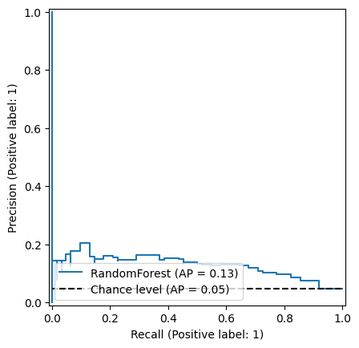

```python
X = df_enc_scaled.drop(['stroke'], axis=1)
y = df_enc_scaled['stroke']

X_train, X_test, y_train, y_test = train_test_split(X, y, stratify=y, random_state=1)

forest_scaled = RandomForestClassifier(random_state=1)
forest_scaled.fit(X_train, y_train)

preds_scaled = forest.predict(X_test)
acc_scaled = accuracy_score(y_test, preds)
print('accuracy: ', acc_scaled)

precision_scaled, recall_scaled, _ = precision_recall_curve(y_test, preds_scaled)
print(f'precision: {precision_scaled}, recall: {recall_scaled}')

display_scaled = PrecisionRecallDisplay.from_estimator(
forest_scaled, X_test, y_test, name="RandomForest", plot_chance_level = True, pos_label=1
)
# _ = display.ax_.set_title("2-class Precision-Recall curve")
# display.plot()
```

```python
# from sklearn.naive_bayes import GaussianNB
# gaussian = GaussianNB()
# gaussian.fit(X_train, y_train)
# accuracy_score(y_test, gaussian.predict(X_test))
```

```python
y_test.astype('int').unique()
```

```
array([0, 1])
```

```python
np.unique(preds_scaled)
```

```
array([0], dtype=int64)
```

```python
forest_report_scaled = classification_report(y_test.astype('int'), preds_scaled)
print(forest_report_scaled)
```

```
              precision    recall  f1-score   support

           0       0.95      1.00      0.98      1216
           1       0.00      0.00      0.00        62

    accuracy                           0.95      1278
   macro avg       0.48      0.50      0.49      1278
weighted avg       0.91      0.95      0.93      1278
```

### Function for testing predictions quality - needs true and preds

report and confusion matrix

```python
def clf_report_and_cm(y_true, y_pred):
    report = classification_report(y_true, y_pred, target_names=['no stroke', 'stroke'])
    print('report:')
    print(report)
    cm = confusion_matrix(y_true, y_pred)
    cm_disp = ConfusionMatrixDisplay(confusion_matrix=cm,
                                  display_labels=forest.classes_)
    cm_disp.plot()
```

```
counts:
[[   0 1015]
 [   1  263]]
report:
              precision    recall  f1-score   support

   no stroke       0.97      0.81      0.88      1216
      stroke       0.13      0.55      0.21        62

    accuracy                           0.80      1278
   macro avg       0.55      0.68      0.55      1278
weighted avg       0.93      0.80      0.85      1278
```

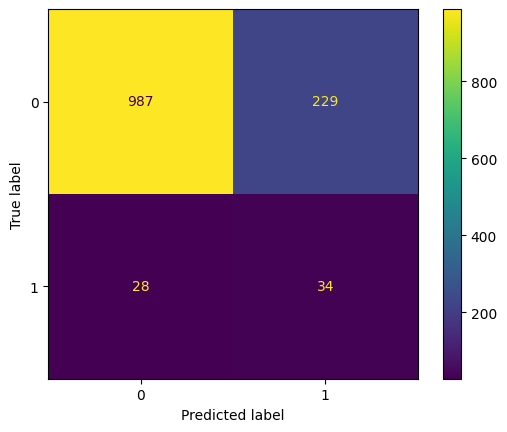

```python
preds_scaled_thresh = (forest_scaled.predict_proba(X_test)[:,1] >= 0.1).astype('int')
unique, counts = np.unique(preds_scaled_thresh, return_counts=True)
print('counts:')
print(np.asarray((unique, counts)).T)
clf_report_and_cm(y_test, preds_scaled_thresh)
```

Unfortunately - no improvement to be seen. It is important to keep it mind - this result does not mean that scaling is useless in predicting on the problem, just that it might not have worked with this particular Random Tree model.

## Class weight explorations

Using scikit-learn, for some alogrithms, a parameter of class weights is available. Setting this parameter is supposed to guide the model training cost functions to assign higher importance to the minority class, by setting it's weight higher, allowing the model to pay more attention to patterns related to this class and reducing the bias towards the majority class.

Let's start with a simple class weights formula, stated as: weight_i = n_samples / (n_classes * n_samples_i)

```python
stroke_weight = df_enc.shape[0] / (2 * df_enc[df_enc['stroke'] == 1].shape[0])
nostroke_weight = df_enc.shape[0] / (2 * df_enc[df_enc['stroke'] == 0].shape[0])
print(f'stroke weight: {stroke_weight}, no stroke: {nostroke_weight}')
```

```
stroke weight: 10.261044176706827, no stroke: 0.5256120139888911
```

#### Let's start without scaling

```
accuracy:  0.9491392801251957
precision: [0.0485133 0.        1.       ], recall: [1. 0. 0.]
```

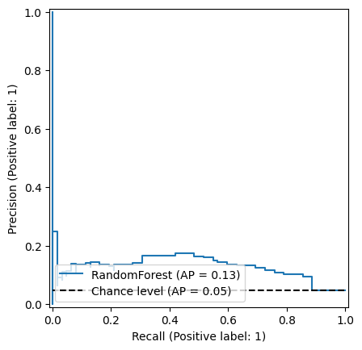

```python
X = df_enc.drop(['stroke'], axis=1)
y = df_enc['stroke']

X_train, X_test, y_train, y_test = train_test_split(X, y, stratify=y, random_state=1)

forest_weighted = RandomForestClassifier(random_state=1, class_weight = {0: nostroke_weight, 1: stroke_weight})
# forest_weighted = RandomForestClassifier(random_state=1, class_weight = "balanced")
forest_weighted.fit(X_train, y_train)

preds_weighted = forest.predict(X_test)
acc_weighted = accuracy_score(y_test, preds)
print('accuracy: ', acc_weighted)

precision_weighted, recall_weighted, _ = precision_recall_curve(y_test, preds_weighted)
print(f'precision: {precision_weighted}, recall: {recall_weighted}')

display_weighted = PrecisionRecallDisplay.from_estimator(
    forest_weighted, X_test, y_test, name="RandomForest", plot_chance_level = True, pos_label=1
)
# _ = display.ax_.set_title("2-class Precision-Recall curve")
# display.plot()
```

```python
forest_weighted_report = classification_report(y_test, preds_weighted, target_names=['no stroke', 'stroke'])
print(forest_weighted_report)
```

```
              precision    recall  f1-score   support

   no stroke       0.95      1.00      0.97      1216
      stroke       0.00      0.00      0.00        62

    accuracy                           0.95      1278
   macro avg       0.48      0.50      0.49      1278
weighted avg       0.91      0.95      0.93      1278
```

No improvement so far, let's experiment with changing the prediction threshold.

```
counts:
[[   0 1044]
 [   1  234]]
report:
              precision    recall  f1-score   support

   no stroke       0.97      0.84      0.90      1216
      stroke       0.15      0.56      0.24        62

    accuracy                           0.82      1278
   macro avg       0.56      0.70      0.57      1278
weighted avg       0.93      0.82      0.87      1278
```

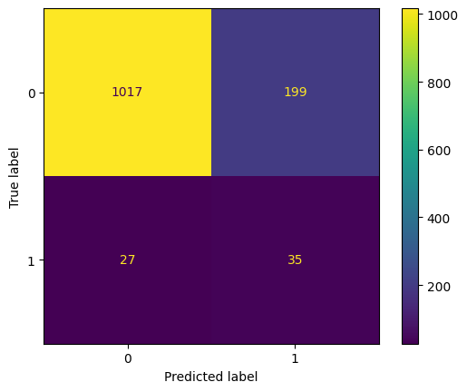

```python
preds_thresh = (forest_weighted.predict_proba(X_test)[:,1] >= 0.1).astype('int')
unique, counts = np.unique(preds_thresh, return_counts=True)
print('counts:')
print(np.asarray((unique, counts)).T)
clf_report_and_cm(y_test, preds_thresh)
```

An improvement! Not a huge one, an improvement nonetheless, with both more 'stroke' occurences predicted correctly and a lower number of false positives.

### Finetuning the random forests model - grid search

perhaps important to mention - so far we mostly used a random train/test split, with stratify=True, which ensures an even proportion of classes in both subsets - very important to achieve accurate testing results, especially with grid searching and cross-validation in mind. A very similar behaviour can be achieved using 'StratifiedKFold' from the same library

```python
param_grid = {
    'min_samples_split': [3, 5, 10],
    'n_estimators' : [100, 300],
    'max_depth': [3, 5, 15, 25],
    'max_features': [3, 5, 10, 20]
}

scorers = {
    'precision_score': make_scorer(precision_score),
    'recall_score': make_scorer(recall_score),
    'accuracy_score': make_scorer(accuracy_score)
}
```

```python
def grid_search_wrapper(clf, refit_score='recall_score'):
    """
    fits a GridSearchCV classifier using refit_score for optimization
    prints classifier performance metrics
    """

    skf = StratifiedKFold(n_splits=10)
    grid_search = GridSearchCV(clf, param_grid, scoring=scorers, refit=refit_score,
                           cv=skf, return_train_score=True, n_jobs=-1)
    grid_search.fit(X_train.values, y_train.values)

    # make the predictions
    y_pred = grid_search.predict(X_test.values)

    print('Best params for {}'.format(refit_score))
    print(grid_search.best_params_)

    # confusion matrix on the test data.
    print('\nConfusion matrix of Random Forest optimized for {} on the test data:'.format(refit_score))
    print(pd.DataFrame(confusion_matrix(y_test, y_pred),
                 columns=['pred_neg', 'pred_pos'], index=['neg', 'pos']))
    return grid_search
```

```python
X_train, X_test, y_train, y_test = train_test_split(X, y, stratify=y, random_state=1)
clf = RandomForestClassifier(n_jobs=-1, random_state=1, class_weight={0: nostroke_weight, 1: stroke_weight})

grid_search_clf = grid_search_wrapper(clf, refit_score='recall_score')
```

```
Best params for recall_score
{'max_depth': 3, 'max_features': 3, 'min_samples_split': 3, 'n_estimators': 100}

Confusion matrix of Random Forest optimized for recall_score on the test data:
     pred_neg  pred_pos
neg       838       378
pos        13        49
```

```python
results = pd.DataFrame(grid_search_clf.cv_results_)
results = results.sort_values(by='mean_test_recall_score', ascending=False)
results[['mean_test_precision_score', 'mean_test_recall_score', 'mean_test_accuracy_score', 'param_max_depth', 'param_max_features', 'param_min_samples_split', 'param_n_estimators']].round(3).head()
```

|  | mean_test_precision_score | mean_test_recall_score | mean_test_accuracy_score | param_max_depth | param_max_features | param_min_samples_split | param_n_estimators |
| --- | --- | --- | --- | --- | --- | --- | --- |
| 0 | 0.128 | 0.866 | 0.706 | 3 | 3 | 3 | 100 |
| 2 | 0.129 | 0.866 | 0.707 | 3 | 3 | 5 | 100 |
| 4 | 0.128 | 0.866 | 0.706 | 3 | 3 | 10 | 100 |
| 11 | 0.128 | 0.861 | 0.708 | 3 | 5 | 10 | 300 |
| 17 | 0.130 | 0.861 | 0.713 | 3 | 10 | 10 | 300 |

### From: https://towardsdatascience.com/fine-tuning-a-classifier-in-scikit-learn-66e048c21e65

```python
y_scores = grid_search_clf.predict_proba(X_test)[:, 1]
```

```python
p, r, thresholds = precision_recall_curve(y_test, y_scores)
```

```python
def plot_precision_recall_vs_threshold(precisions, recalls, thresholds):
    """
    Modified from:
    Hands-On Machine learning with Scikit-Learn
    and TensorFlow; p.89
    """
    plt.figure(figsize=(8, 8))
    plt.title("Precision and Recall Scores as a function of the decision threshold")
    plt.plot(thresholds, precisions[:-1], "b--", label="Precision")
    plt.plot(thresholds, recalls[:-1], "g-", label="Recall")
    plt.ylabel("Score")
    plt.xlabel("Decision Threshold")
    plt.legend(loc='best')
```

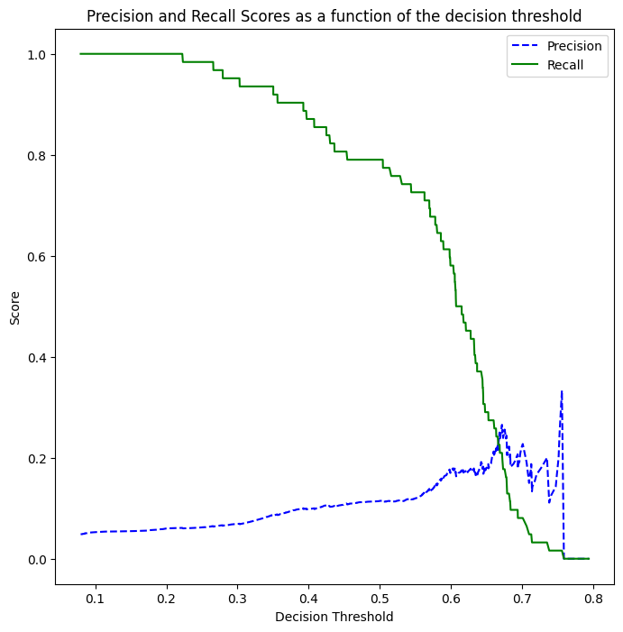

```python
# use the same p, r, thresholds that were previously calculated
plot_precision_recall_vs_threshold(p, r, thresholds)
```

```python
best_model = grid_search_clf.best_estimator_
best_model
```

```
RandomForestClassifier(class_weight={0: 0.5256120139888911,
                                     1: 10.261044176706827},
                       max_depth=3, max_features=3, min_samples_split=3,
                       n_jobs=-1, random_state=1)
```

Interestingly, the best model under these circumstances, appears to be the simplest one, with the lowest depth and the smallest amount of features

```python
best_model.feature_importances_
```

```
array([0.43367845, 0.0499401 , 0.07944236, 0.09288   , 0.1141729 ,
       0.10783124, 0.02770156, 0.00366858, 0.00200927, 0.        ,
       0.00354886, 0.00141506, 0.00349572, 0.0188766 , 0.0543226 ,
       0.00269245, 0.00432424])
```

#### threshold tuning

```
counts:
[[  0 851]
 [  1 427]]
report:
              precision    recall  f1-score   support

   no stroke       0.98      0.69      0.81      1216
      stroke       0.11      0.79      0.20        62

    accuracy                           0.69      1278
   macro avg       0.55      0.74      0.51      1278
weighted avg       0.94      0.69      0.78      1278
```

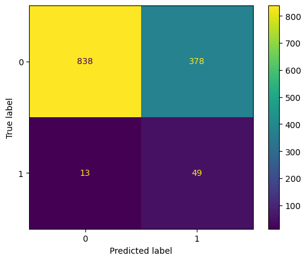

```python
preds_thresh = (best_model.predict_proba(X_test)[:,1] >= 0.5).astype('int')
unique, counts = np.unique(preds_thresh, return_counts=True)
print('counts:')
print(np.asarray((unique, counts)).T)
clf_report_and_cm(y_test, preds_thresh)
```

For a well-fitted model, with weights adapted, threshold tuning does not yield much improvement, it seems the precision-reall tradeoff is immovable, in every one of our tested cases, an increase in true positives comes with an increase of false positives. Although, with this in mind, our best (so far) model, has managed to achieve an almost 80% stroke detection rate - with a 30% chance of a false positive.

To continue the research, let's examine the performance of other types of models

### SVC, logisticregression, MLPClassifier, AdaBoost

```python
classifiers = [
    SVC(random_state=1),
    MLPClassifier(random_state=1),
    AdaBoostClassifier(random_state=1),
    LogisticRegression(random_state=1)
]
```

```python
clf_names = [
    'svc',
    'mlp',
    'adaboost',
    'logreg'
]
```

```python
for clf_i, clf in enumerate(classifiers):
    clf.fit(X_train, y_train)
    clf_preds = clf.predict(X_test)
    clf_report = classification_report(y_test, clf_preds, target_names=['no stroke', 'stroke'])
    print(f"Alg: {clf_names[clf_i]}")
    print(clf_report)
```

```
Alg: svc
              precision    recall  f1-score   support

   no stroke       0.95      1.00      0.98      1216
      stroke       0.00      0.00      0.00        62

    accuracy                           0.95      1278
   macro avg       0.48      0.50      0.49      1278
weighted avg       0.91      0.95      0.93      1278

Alg: mlp
              precision    recall  f1-score   support

   no stroke       0.95      1.00      0.97      1216
      stroke       0.33      0.02      0.03        62

    accuracy                           0.95      1278
   macro avg       0.64      0.51      0.50      1278
weighted avg       0.92      0.95      0.93      1278

Alg: adaboost
              precision    recall  f1-score   support

   no stroke       0.95      1.00      0.97      1216
      stroke       0.00      0.00      0.00        62

    accuracy                           0.95      1278
   macro avg       0.48      0.50      0.49      1278
weighted avg       0.91      0.95      0.93      1278

Alg: logreg
              precision    recall  f1-score   support

   no stroke       0.95      1.00      0.97      1216
      stroke       0.00      0.00      0.00        62

    accuracy                           0.95      1278
   macro avg       0.48      0.50      0.49      1278
weighted avg       0.91      0.95      0.93      1278
```

It would seem a basic MLP algorithm predicted more than 0 times for the 'stroke' class! Let's explore further

### MLPClassifier

```
<sklearn.metrics._plot.confusion_matrix.ConfusionMatrixDisplay at 0x18ef76a23e0>
```

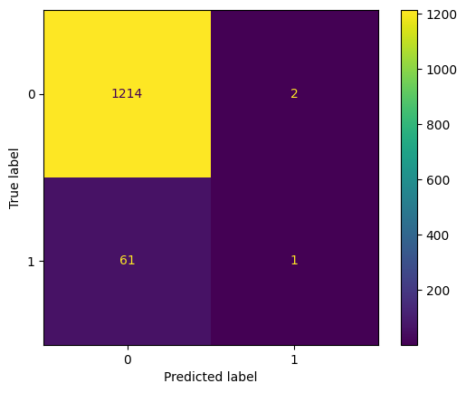

```python
mlp_c = MLPClassifier(random_state=1)
mlp_c.fit(X_train, y_train)
mlp_c_preds = mlp_c.predict(X_test)
cm = confusion_matrix(y_test, mlp_c_preds, labels=mlp_c.classes_)
cm_disp = ConfusionMatrixDisplay(confusion_matrix=cm,
                              display_labels=mlp_c.classes_)
cm_disp.plot()
```

Okay, let's try finetuning the model

#### MLP prediction threshold

Let's try to match the resutls from the best random forest model

```
counts:
[[  0 840]
 [  1 438]]
report:
              precision    recall  f1-score   support

   no stroke       0.98      0.68      0.80      1216
      stroke       0.11      0.77      0.19        62

    accuracy                           0.68      1278
   macro avg       0.55      0.73      0.50      1278
weighted avg       0.94      0.68      0.77      1278
```

```
<sklearn.metrics._plot.confusion_matrix.ConfusionMatrixDisplay at 0x18ef765a560>
```

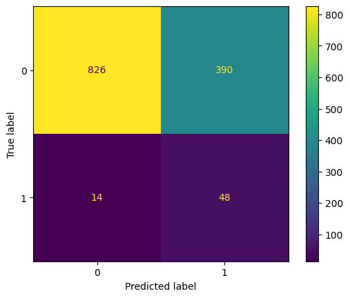

```python
preds_thresh = (mlp_c.predict_proba(X_test)[:,1] >= 0.06).astype('int')
unique, counts = np.unique(preds_thresh, return_counts=True)
print('counts:')
print(np.asarray((unique, counts)).T)
mlp_thresh_report = classification_report(y_test, preds_thresh, target_names=['no stroke', 'stroke'])
print('report:')
print(mlp_thresh_report)
cm_thresh = confusion_matrix(y_test, preds_thresh)
cm_disp_thresh = ConfusionMatrixDisplay(confusion_matrix=cm_thresh,
                              display_labels=mlp_c.classes_)
cm_disp_thresh.plot()
```

It seems, we can do just that, unfortunately, with the same tradeoff of false positives.

```python
# warning: long running cell - gridsearch over another algorithms, which could theoretically perform well
```

```python
# parameters = {'kernel':('linear', 'rbf'), 'C':[1, 10]}
# svc = SVC()
# clf = GridSearchCV(svc, parameters)
# clf.fit(X, y)
# sorted(clf.cv_results_.keys())
```

#### More complex MLP classifier

```
<sklearn.metrics._plot.confusion_matrix.ConfusionMatrixDisplay at 0x18ef77e34c0>
```

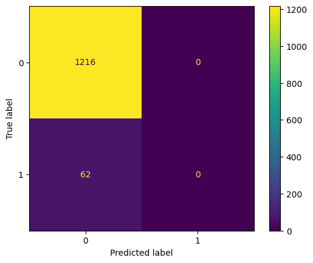

```python
mlp_c = MLPClassifier(hidden_layer_sizes = (100,10,10), alpha=0.001,
                      learning_rate='adaptive', max_iter = 500,
                      early_stopping=True, random_state=1)
mlp_c.fit(X_train, y_train)
mlp_c_preds = mlp_c.predict(X_test)
cm = confusion_matrix(y_test, mlp_c_preds, labels=mlp_c.classes_)
cm_disp = ConfusionMatrixDisplay(confusion_matrix=cm,
                              display_labels=mlp_c.classes_)
cm_disp.plot()
```

#### MLPclassifier with scaled features

```python
X = df_enc_scaled.drop(['stroke'], axis=1)
y = df_enc_scaled['stroke']

X_train, X_test, y_train, y_test = train_test_split(X, y, stratify=y, random_state=1)
```

```
<sklearn.metrics._plot.confusion_matrix.ConfusionMatrixDisplay at 0x18ef7956bf0>
```

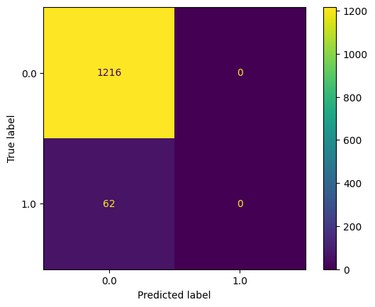

```python
mlp_c = MLPClassifier(hidden_layer_sizes = (100,10,10), alpha=0.001,
                      learning_rate='adaptive', max_iter = 500,
                      early_stopping=True, random_state=1)
mlp_c.fit(X_train, y_train)
mlp_c_preds = mlp_c.predict(X_test)
cm = confusion_matrix(y_test, mlp_c_preds, labels=mlp_c.classes_)
cm_disp = ConfusionMatrixDisplay(confusion_matrix=cm,
                              display_labels=mlp_c.classes_)
cm_disp.plot()
```

```
counts:
[[   1 1278]]
report:
              precision    recall  f1-score   support

   no stroke       0.00      0.00      0.00      1216
      stroke       0.05      1.00      0.09        62

    accuracy                           0.05      1278
   macro avg       0.02      0.50      0.05      1278
weighted avg       0.00      0.05      0.00      1278
```

```
<sklearn.metrics._plot.confusion_matrix.ConfusionMatrixDisplay at 0x18ef7fca050>
```

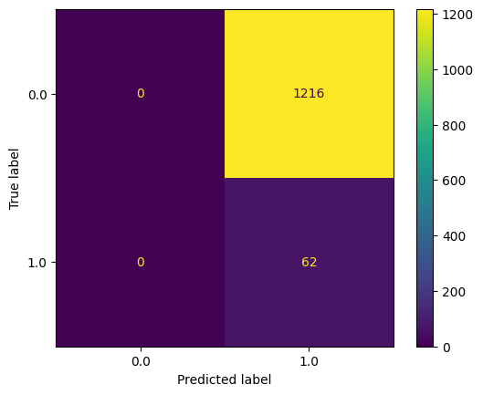

```python
preds_thresh = (mlp_c.predict_proba(X_test)[:,1] >= 0.1).astype('int')
unique, counts = np.unique(preds_thresh, return_counts=True)
print('counts:')
print(np.asarray((unique, counts)).T)
mlp_thresh_report = classification_report(y_test, preds_thresh, target_names=['no stroke', 'stroke'])
print('report:')
print(mlp_thresh_report)
cm_thresh = confusion_matrix(y_test, preds_thresh)
cm_disp_thresh = ConfusionMatrixDisplay(confusion_matrix=cm_thresh,
                              display_labels=mlp_c.classes_)
cm_disp_thresh.plot()
```

```
counts:
[[  0 590]
 [  1 688]]
report:
              precision    recall  f1-score   support

   no stroke       0.94      0.45      0.61      1216
      stroke       0.04      0.40      0.07        62

    accuracy                           0.45      1278
   macro avg       0.49      0.43      0.34      1278
weighted avg       0.89      0.45      0.59      1278
```

```
<sklearn.metrics._plot.confusion_matrix.ConfusionMatrixDisplay at 0x18ef77e08b0>
```

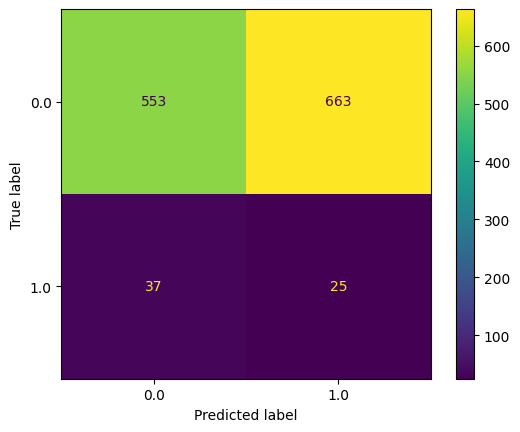

```python
preds_thresh = (mlp_c.predict_proba(X_test)[:,1] >= 0.2).astype('int')
unique, counts = np.unique(preds_thresh, return_counts=True)
print('counts:')
print(np.asarray((unique, counts)).T)
mlp_thresh_report = classification_report(y_test, preds_thresh, target_names=['no stroke', 'stroke'])
print('report:')
print(mlp_thresh_report)
cm_thresh = confusion_matrix(y_test, preds_thresh)
cm_disp_thresh = ConfusionMatrixDisplay(confusion_matrix=cm_thresh,
                              display_labels=mlp_c.classes_)
cm_disp_thresh.plot()
```

It seems, a more complex neural network model is very susceptible to threshold changes - not exactly a stable model to work with.

### Results before feature engineering

So far, our best performing (and simplest) model so far has been a random forest model, achieving a true positive rate of 80%, with a false rate positive of 30%, chosen with the goal of maximing the TP rate, without exploding the FP rate.

```python
best_model.get_params
```

```
<bound method BaseEstimator.get_params of RandomForestClassifier(class_weight={0: 0.5256120139888911,
                                     1: 10.261044176706827},
                       max_depth=3, max_features=3, min_samples_split=3,
                       n_jobs=-1, random_state=1)>
```